# london

JustinJDavies

19 June 2017

## Dataset

We have a response variable showing the total quotes per enquiry from a popular online price comparison website, grouped by London postcodes. A (not particularly) sample of (up to) 100 records for each London postcode district have been selected as a development dataset. Some postcode districts have fewer than 100 quotes in total.

```r
d <- read.delim2('londonPostQuote', header = T)

summary(d %>% select(PostcodeArea, Quotes))
```

```
##   PostcodeArea      Quotes
##  SE     :2800   Min.   : 1.00
##  SW     :2252   1st Qu.:29.00
##  N      :2207   Median :50.00
##  E      :2000   Mean   :48.87
##  W      :1540   3rd Qu.:70.00
##  NW     :1100   Max.   :99.00
##  (Other): 798
```

```r
result <-
    d %>%
    group_by(PostcodeArea) %>%
    mutate(pc2 = dense_rank(PostcodeOutward)) %>%
    mutate(pc1 = as.numeric(PostcodeArea)) %>%
    ungroup()
```

## Summary Plots

### Spatial plot (TODO)

https://cran.r-project.org/doc/contrib/intro-spatial-rl.pdf

### Total Quotes

It is possible that there is a systematic discrimination bewteen the quotability (number of quotes per enquiry) for each Postcode Area.

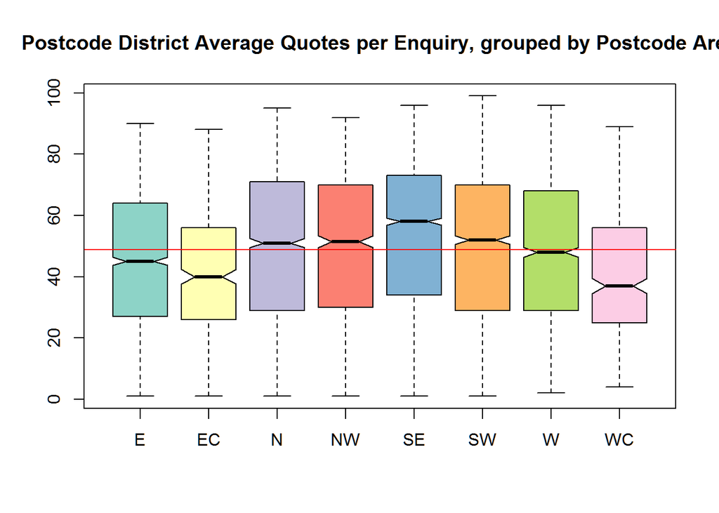

It is not clear if this is driven by indiviual Postcode Districts.

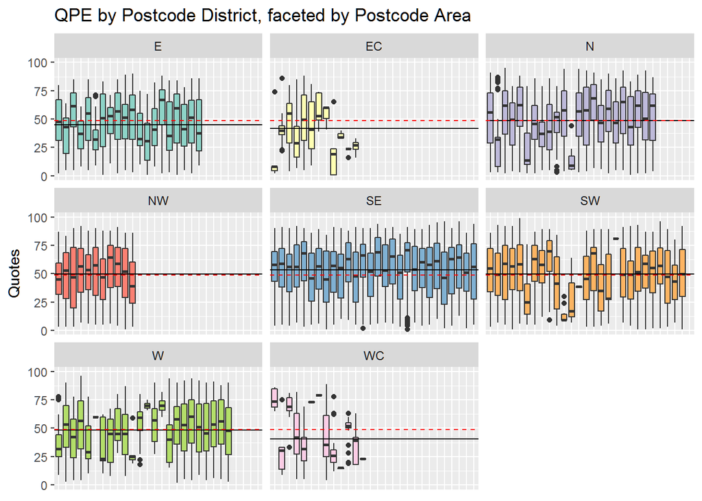

## Model form

What is the best option for modelling the expected quotability of an enquiry, given the postcode area and district?

### Simple GLM

Indications from GLM analysis suggest that there are significant trends at both the Postcode Area and Postcode District level.

```r
g <- glm(
        formula = Quotes ~ PostcodeArea,
        family = poisson(link = "log"),
        data = result
        )

summary(g)
```

```
##
## Call:
## glm(formula = Quotes ~ PostcodeArea, family = poisson(link = "log"),
##     data = result)
##
## Deviance Residuals:
##     Min       1Q   Median       3Q      Max
## -9.8480  -2.9863   0.2182   2.6895   6.5864
##
## Coefficients:
##                 Estimate Std. Error  z value Pr(>|z|)
## (Intercept)     3.809724   0.003328 1144.690   <2e-16 ***
## PostcodeAreaEC -0.081980   0.008393   -9.767   <2e-16 ***
## PostcodeAreaN   0.077982   0.004512   17.282   <2e-16 ***
## PostcodeAreaNW  0.093074   0.005425   17.158   <2e-16 ***
## PostcodeAreaSE  0.169403   0.004214   40.202   <2e-16 ***
## PostcodeAreaSW  0.091333   0.004478   20.394   <2e-16 ***
## PostcodeAreaW   0.064893   0.004956   13.095   <2e-16 ***
## PostcodeAreaWC -0.110844   0.008605  -12.881   <2e-16 ***
## ---
## Signif. codes:  0 '***' 0.001 '**' 0.01 '*' 0.05 '.' 0.1 ' ' 1
##
## (Dispersion parameter for poisson family taken to be 1)
##
##     Null deviance: 164446  on 12696  degrees of freedom
## Residual deviance: 161566  on 12689  degrees of freedom
## AIC: 232083
##
## Number of Fisher Scoring iterations: 4
```

If we fit (overfit) every postcode district, we can see that some are liklely significantly discriminated and some are not.

```r
g <- glm(
        formula = Quotes ~ PostcodeOutward,
        family = poisson(link = "log"),
        data = result
        )

summary(g)
```

```
##
## Call:
## glm(formula = Quotes ~ PostcodeOutward, family = poisson(link = "log"),
##     data = result)
##
## Deviance Residuals:
##      Min        1Q    Median        3Q       Max
## -10.6485   -2.7524    0.2607    2.4451   10.1280
##
## Coefficients:
##                       Estimate Std. Error z value Pr(>|z|)
## (Intercept)          3.8475911  0.0146052 263.441  < 2e-16 ***
## PostcodeOutwardE10  -0.2615753  0.0221449 -11.812  < 2e-16 ***
## PostcodeOutwardE11   0.1868265  0.0197553   9.457  < 2e-16 ***
## PostcodeOutwardE12  -0.2882511  0.0223134 -12.918  < 2e-16 ***
## PostcodeOutwardE13   0.0706127  0.0202997   3.479 0.000504 ***
## PostcodeOutwardE14  -0.3277222  0.0225686 -14.521  < 2e-16 ***
## PostcodeOutwardE15   0.0169209  0.0205680   0.823 0.410690
## PostcodeOutwardE16   0.0302544  0.0205003   1.476 0.139998
## PostcodeOutwardE17   0.1162650  0.0200800   5.790 7.04e-09 ***
## PostcodeOutwardE18   0.0452490  0.0204251   2.215 0.026735 *
## PostcodeOutwardE1W   0.1101698  0.0201089   5.479 4.29e-08 ***
## PostcodeOutwardE2   -0.2299392  0.0219492 -10.476  < 2e-16 ***
## PostcodeOutwardE20  -0.4168350  0.0231719 -17.989  < 2e-16 ***
## PostcodeOutwardE3   -0.0849967  0.0211079  -4.027 5.65e-05 ***
## PostcodeOutwardE4    0.2268908  0.0195786  11.589  < 2e-16 ***
## PostcodeOutwardE5   -0.1675002  0.0215759  -7.763 8.27e-15 ***
## PostcodeOutwardE6    0.0797145  0.0202553   3.935 8.30e-05 ***
## PostcodeOutwardE7   -0.0959717  0.0211685  -4.534 5.80e-06 ***
## PostcodeOutwardE8    0.0055308  0.0206263   0.268 0.788591
## PostcodeOutwardE9   -0.0675008  0.0210123  -3.212 0.001316 **
## PostcodeOutwardEC1A -1.0046216  0.0995942 -10.087  < 2e-16 ***
## PostcodeOutwardEC1M -0.1496866  0.0220356  -6.793 1.10e-11 ***
## PostcodeOutwardEC1N  0.0052125  0.0272730   0.191 0.848429
## PostcodeOutwardEC1R -0.3468642  0.0237526 -14.603  < 2e-16 ***
## PostcodeOutwardEC1V  0.0632311  0.0203360   3.109 0.001875 **
## PostcodeOutwardEC1Y -0.0514662  0.0252396  -2.039 0.041440 *
## PostcodeOutwardEC2A  0.2059314  0.0607086   3.392 0.000694 ***
## PostcodeOutwardEC2N  0.1352009  0.0801529   1.687 0.091644 .
## PostcodeOutwardEC2Y -0.7565487  0.0964566  -7.843 4.38e-15 ***
```

[output cut: 124 more lines]

```
## PostcodeOutwardWC2B -0.4990375  0.0395558 -12.616  < 2e-16 ***
## PostcodeOutwardWC2E -1.1620138  0.1514615  -7.672 1.69e-14 ***
## PostcodeOutwardWC2H  0.0275703  0.0346620   0.795 0.426379
## PostcodeOutwardWC2N -0.2336747  0.0566332  -4.126 3.69e-05 ***
## PostcodeOutwardWC2R -0.7120969  0.1212686  -5.872 4.30e-09 ***
## ---
## Signif. codes:  0 '***' 0.001 '**' 0.01 '*' 0.05 '.' 0.1 ' ' 1
##
## (Dispersion parameter for poisson family taken to be 1)
##
##     Null deviance: 164446  on 12696  degrees of freedom
## Residual deviance: 147465  on 12539  degrees of freedom
## AIC: 218281
##
## Number of Fisher Scoring iterations: 5
```

How can we automatically balance between these two without extensive manual selection of postcode District parameters?